# Markov Chain Monte Carlo Based Terrain Aided Navigation

IYSE6420

Michael Walker

November 30 2023

The advent of the Global Positioning System (GPS) has made precision navigation ubiquitous across the planet. However, the availability of GPS is often taken for granted considering how easily GPS service can be denied via jamming. Furthermore, research missions to the moon and other planets can not use a system like GPS for radio navigation and putting a system like that in place is cost prohibitive. This means that alternative navigation schemes are of great interest in many domains.

For this project we will consider navigation of a flying body in a GPS denied environment via Terrain Aided Navigation (TAN). TAN solutions have been investigated for quite some time [1,2,3].

This project will aim to implement a Bayseian approach to TAN solution using pyMC and measurements from a radar altimeter aboard a flying vehicle.

Why pursue a Bayesian approach?

Typically, aerospace applications employ Extended Kalman Filters (EKF) for solving navigation related problems. Kalman filters assume that there is a linear relationship between the measurements and the state vector. EKF variants of the Kalman Filter can handle non-linear relationships but critically require that the relationship between the measurement and the state vector be linearizable. This is achieved by taking the partial derivatives of the measurement equation relative to the state vector.

There are no equations that govern the terrain height of the earth or any other celestial body. This makes it extremely difficult to directly formulate a EKF based navigation solution directly as partial derivatives of the surface would have to be taken numerically and would contain lots of false minima.

However, if we could formulate a method to determine the current position and velocity of the vehicle based on the terrain it has previously flown over then this data could be fed into a Kalman Filter as direct measurements of the state vector. This would be ideal! In addition to measurements the Kalman Filter requires estimates of the noise on the measurements represented as a covariance. As a whole we can view this as the Kalman Filter expecting measurements as distributions not as discrete values.

This sure sounds like a problem that is asking for a Bayseian solution.

In this project I will explore several cases of the TAN problem:

1. The flight of a vehicle over 2-dimensional terrain sampled from the Earth
2. The flight of a vehicle over 3-dimensional terrain sampled from the Earth

While other more complex methods such as particle filters exist to solve this sort of problem this project will focus on a purely MCMC baesd approach

# Part 1: The 2-Dimensional case

As a way to start exploring this problem I will explore a 1-dimensional case of the problem presented. For this problem the following simplifying assumptions are made.

- The aircraft is maintaining steady level flight
- The aircraft is flying at a fixed latitude.
- Altimeter measurements are generated by flying a simulated trajectory over the earth and sampling terrain height from the GTOP digital elevation model which is sampled every 30 arc seconds around the Earth (30 arc seconds is equivalent to 0.008333 degrees).

[figure not shown]

## 2-D Equations of Motion

The equations of motion for steady level flight in two dimensions are simple:

$$ X(t) = X_0 + V(t) \cdot t \\ H(t) = H_0 \\ V(t) = V_0 \\ M = f(x) $$

Where the variables of interest are defined:

| Variable | Description |
| --- | --- |
| $X$ | Position |
| $V$ | Velocity |
| $H$ | Altitude above sea level |
| $t$ | Time |
| $M$ | Terrain height based on terrain map $f(x)$ |

A ranging device will take measurements of distance from the aircraft to the terrain which means that the measurement of interest can be defined as:

$$ A = H - M + \epsilon = H_0 - M + \epsilon $$

Where $\epsilon$ is normally distributed measurement noise.

## 2-D Bayesian Network

Based on these equations of motion and the available measurement a Bayseian Network can be defined that models the equations of motion. The network will be setup in a way such that when it is sampled via a MCMC method posterior estimates of the initial conditions emerge.

The problem will start by defining uniform priors for $X_0$, $V_0$ and $H_0$. These flat priors are meant to represent proior that is defines the bounds of the area to be searched but otherwise is uninformative.

$$ X_0 \sim U( X_{0L} , X_{0U} ) \\ H_0 \sim U( H_{0L} , H_{0U} ) \\ V_0 \sim U( V_{0L} , V_{0U} ) $$

An non-informative gamma distribution will also be selected as the prior for precision hyperparameter of the altimeter

$$ \tau \sim \text{Gamma} \left( \tau_0, 1 \right) $$

The equations of motion defined above can be applied deterministically to these parameters as follows:

$$ X = V_0 \cdot t + X_0 \\ M = f( X )\\ \mu_A = H_0 - M $$

The likelihood function for the altimeter measurements is then given as:

$$ L( A | \mu_A , \sigma ) \sim N\left( \mu_A, \sigma \right) $$

It's worth noting that this network is a variation of a linear regression model where $V_0$ is a slope, $X_0$ and $H_0$ are intercepts, and the map function is similar to a link function. In this case however the link function maps a position to a terrain height instead of to a logistic curve.

## Numerical Conditioning

In order to keep the problem well conditioned mathematically the following basic linear transformations are applied to the data.

- Time $t$ is non-dimensionalized such that it always runs from 0-1
- Velocity $V_0$ is therefore a measure of how far the aircraft flies during the time of interest. This means "fast trajectories" cover more ground in this format.
- Altitude $H_0$ is measured in kilometers (km)
- $X_0$ is longitude in degrees
- $\sigma$ is in units of $km$

The difference in units must be corrected for when plugging $\tau$ into the likelihood function however is helpful to keep the problem numerically conditioned.

## Understanding the priors and the search space

A valid question at this point is "Why select bounded uniform priors". The answer for this is simple - for the scope of this problem its advantageous to limit the search space given that each pixel of the terrain data is 0.008333 degrees ( 30 arc-seconds ). That means that a search space of 10 degrees is aproximately 1200 pixels. The model needs to visit these pixels in order to find the correct trajectory of the flight. The search space can be increased but then more samples are requied. While the other parameters dont correlate directly to pixel density of the map they do increase the number of samples needed in order to properly visit the space being searched. Using bounded uniform priors allows us to use a prior that is mostly non-informative without totally blowing up the search space.

In a real aircraft its more likely that an informative prior would be available and that that prior would be a normal distribution. Therefore, the performance of this estimator with bounded uniform priors should out-perform the "realisitc" use case.

## Application Case1: Landfall and Mountainous Terrain

The model described can be applied against an example trajectory in order to evaluate its performance. Below the experiment will be setup and summarized:

```python
import dim_1 as m
import warnings
warnings.filterwarnings('ignore')
from IPython.display import Markdown as md
case1 = m.Solver(
      x0=-130 ,
      v0=10,
      h0=8,
      xBounds=[-132,-123],
      vBounds=[9.5,11],
      hBounds=[7.7,8.1],
      sigma=0.01,
      n=10000
)

md( case1.flight_summary() )
```

| Variable | Value | Units | Description |
| --- | --- | --- | --- |
| $X_0$ | -130 | degrees | The initial longitude of the flight |
| $V_0$ | 10 | degrees | The velocity of the flight. Since time is non dimensional from 0-1 this is equivalent to the distance traveled |
| $H_0$ | 8 | km | Altitude of the flight |
| $\sigma$ | 0.01 | km | Standard deviation of noise on the altimeter measurement |

The priors on the initial conditions are selected as follows note that all priors are biased from the real answer.

```python
md( case1.prior_summary( ))
```

| Prior | Lower Bound | Upper Bound |
| --- | --- | --- |
| $X_0$ | -132 | -123 |
| $V_0$ | 9.5 | 11 |
| $H_0$ | 7.7 | 8.1 |

Plotting the altitude against time show that the altimeter measurements are quite unique as a function of trajectory. It also shows that the altimeter measurements, as expected, do no follow any specific mathmateical function. This makes sense as they measure the altitude map of the earth. A few notable things happen in this trajectory. Since we are dealing with a simulated trajectory we know about it in advance and can use this advance knowledge to have understanding of the estimator's performance

| Time Range | Description |
| --- | --- |
| 0-0.2 | Flying over the ocean |
| 0.2-0.5 | Flying over moutainous terrain in western canada |
| 0.5-1 | Flying over rolling hills and plains in mid-canada |

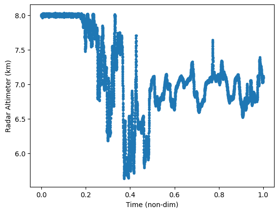

```python
case1.plot_altimeter(1)
```

```python
case1.run( samples=20000)
```

The summary parameters show that the Bayseian model correctly estimates the initial conditions of flight. Notably it lands on the correct values so tightly that arviz reports their standard deviations as zero, this is suspect from arviz and plotting the posteriors show that these are not zero standard deviation distributions they just have very small standard distributions. Thats an extremely high level of confidence and the answers it calcualted are correct. Its also noteworthy that the estimator correctly characterizes the measurement noise in the altimeter. Cool!

```python
import arviz as az
az.summary( case1.trace ,  var_names=["X0","H0","V0", "Sigma"])
```

|  | mean | sd | hdi_3% | hdi_97% | mcse_mean | mcse_sd | ess_bulk | ess_tail | r_hat |
| --- | --- | --- | --- | --- | --- | --- | --- | --- | --- |
| X0 | -130.00 | 0.0 | -130.00 | -130.00 | 0.0 | 0.0 | 5863.0 | 12390.0 | 1.0 |
| H0 | 8.00 | 0.0 | 8.00 | 8.00 | 0.0 | 0.0 | 82487.0 | 59715.0 | 1.0 |
| V0 | 10.00 | 0.0 | 10.00 | 10.00 | 0.0 | 0.0 | 5818.0 | 12066.0 | 1.0 |
| Sigma | 0.01 | 0.0 | 0.01 | 0.01 | 0.0 | 0.0 | 80973.0 | 62318.0 | 1.0 |

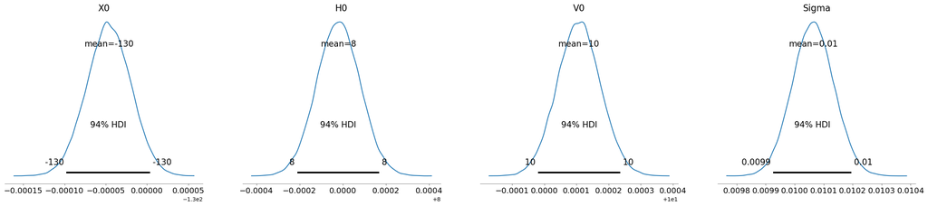

```python
case1.posterior_initial( 4 )
```

While its good that this method can calculate the intiail conditions it is much more interesting to find values for position $X$ over the time history of altimeter measurements. This time history of $X$ and the variance of these measurements can be used as measurements in a traditional Kalman Filter. To understand the performance of the estimator at properly determining these values the posterior of $X$ is compared to the predicted value of $X$ at each altimeter measurement. Since $X$ is increasing linearly its hard to understand the plot without detrending it.

Therefore the error in $X$ predcition is inspected where:

$$ \epsilon_X = X - \hat{X} $$

Below the plots for the 95% credible set of the error is shown.

What does the credible set of the error tell us.

1. The maximum error of the 95% credible set is on the order of 0.0001 degrees, the map data we are using has a pixel resolution of 30 arc-seconds which equates to 0.0083333 degrees. That means that the credible set is inside of approximately 1/83.3 pixels. That is a pretty great sub pixel resolution.
2. The error is not mean zero for all time, there does appear to be a linear bias. This is caused by uncertainty and error in the estimate of $V_0$
3. The credible set has the narrowest width between 0.2 and 0.5 and grows if the time is before or after that window. Its interesting to note that this coincides with landfall of the aircraft and with the most variable (mountainous) terrain. It makes sense that measuring altitude over the ocean provides no information and that flatter areas like the great planes provide less information as moving from pixel to pixel provides less of a difference in altitude. This causes the uncertainty to grow over these areas.

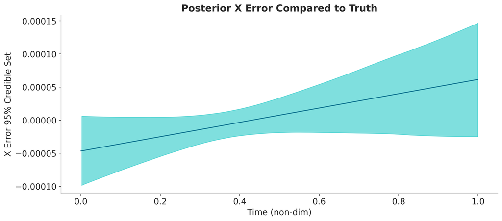

```python
case1.plot_x_credible(3)
```

## Applicaction Case 2: Flatter Terrain and Terrible Altimeters

Lets conduct the same experiment however this time lets give the estimator less to work with. Lets conduct the entire flight over the great plains of Canada and increase the altimeter noise.

```python
case2= m.Solver(
      x0=-112 ,
      v0=10,
      h0=8,
      xBounds=[-120,-110],
      vBounds=[9.5,11],
      hBounds=[7.7,8.1],
      sigma=0.05,
      n=10000
)

md( case2.flight_summary() )
```

| Variable | Value | Units | Description |
| --- | --- | --- | --- |
| $X_0$ | -112 | degrees | The initial longitude of the flight |
| $V_0$ | 10 | degrees | The velocity of the flight. Since time is non dimensional from 0-1 this is equivalent to the distance traveled |
| $H_0$ | 8 | km | Altitude of the flight |
| $\sigma$ | 0.05 | km | Standard deviation of noise on the altimeter measurement |

For this experiment the priors will be the same sort of bounded uniform priors used in case 1

```python
md( case2.prior_summary() )
```

| Prior | Lower Bound | Upper Bound |
| --- | --- | --- |
| $X_0$ | -120 | -110 |
| $V_0$ | 9.5 | 11 |
| $H_0$ | 7.7 | 8.1 |

The altitude plot in this simulation shows that the terrain is much more boring in this case and the altimeter measurements are far more noisy. Its much harder in this example to really see the shape of the terrain.

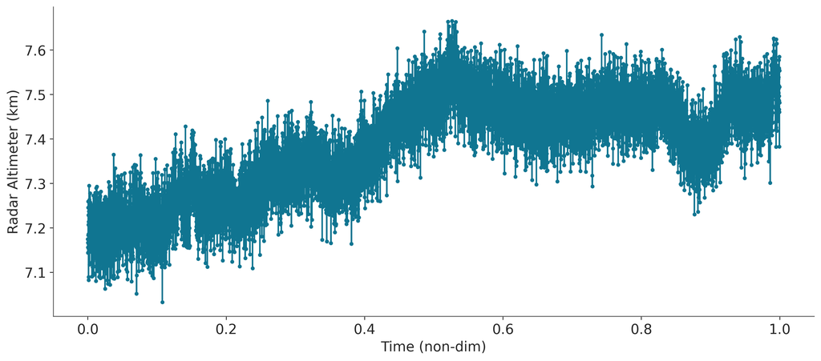

```python
case2.plot_altimeter(5)
```

```python
case2.run( samples=20000 )
```

The poor terain and the altimeter noise in this case start to effect the estimator. Note that in this case arviz actually reports standard deviations as non-zero and the posterior distributions are much wider. However, the estimator still does a pretty good job of estimating the initial conditions of the simulation.

```python
import arviz as az
az.summary( case2.trace ,  var_names=["X0","H0","V0", "Sigma"])
```

|  | mean | sd | hdi_3% | hdi_97% | mcse_mean | mcse_sd | ess_bulk | ess_tail | r_hat |
| --- | --- | --- | --- | --- | --- | --- | --- | --- | --- |
| X0 | -112.000 | 0.001 | -112.002 | -111.997 | 0.0 | 0.0 | 17942.0 | 30892.0 | 1.0 |
| H0 | 8.001 | 0.000 | 8.000 | 8.002 | 0.0 | 0.0 | 78844.0 | 62062.0 | 1.0 |
| V0 | 10.001 | 0.002 | 9.997 | 10.006 | 0.0 | 0.0 | 18127.0 | 30145.0 | 1.0 |
| Sigma | 0.050 | 0.000 | 0.049 | 0.050 | 0.0 | 0.0 | 79870.0 | 60192.0 | 1.0 |

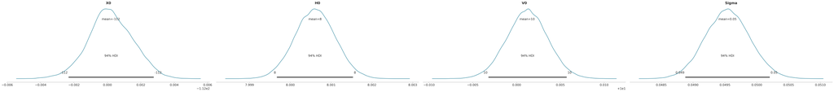

```python
case2.posterior_initial(5)
```

The real interst again lays with the credible set of the error for estimating $X$ at various times. The credible set in this case is on the order of 0.002 to 0.004 which is far worse than in case 1. However, its still worth noting that even with the poor terrain and bad altimeter sub-pixel precision is still achieved by a factor of 2 or 4. Nice!

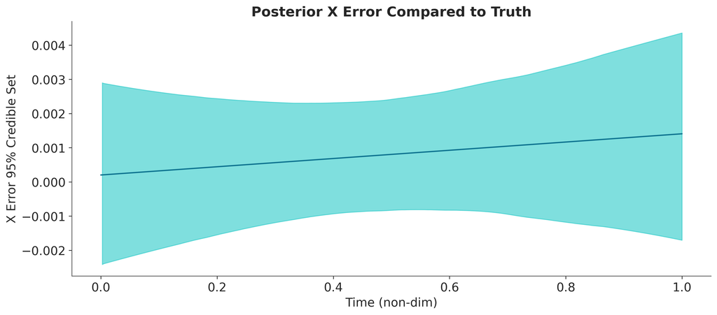

```python
case2.plot_x_credible(6)
```

## Summary of 2-d Estimation

In this section a Bayesian estimator was developed to solve the terrain aided navigation (TAN) problem using only an altimeter. The conditions of flight were simplifed in order to conduct a reasonable experiment. Case 1 showed that promising results can be achieved even if the flight starts over the ocean and specifically that unique/mountainous terrain provides better information for the estimator. Case 2 showed that while mountains are preferred the estimator can still perform with relatively boring terrain and lots of altimeter noise. The real weakness of this section is the assumption of 2-dimensional flight, its totally unrealistic, however this section provided a good way to learn about the estimator without too many variables. In the next part 3-dimensional flight is investigated.

# Part 2: The 3-Dimensional Case

Obviously, aircraft motion does not occur in two dimensions. While the two dimensional case is instructive to learn about Bayesian fitting relative to a map it is not sufficient for real world adaptation.

As in part one serveral simplifying assumptions are made to the scope of this problem:

- The aircraft is maintaining steady level flight.
- Altimeter measurements are generated by flying a simulated trajectory over the earth and sampling terrain height from the GTOP digital elevation model which is sampled every 30 arc seconds around the Earth (30 arc seconds is equivalent to 0.008333 degrees).

## 3-D Equations of Motion

Assuming steady level flight the equations of motion for the aircraft are:

$$ \theta(t) = \theta_0 + V_\theta \cdot t \\ \phi(t) = \phi_0 + V_\phi \cdot t \\ V(t) = V_0 \\ \gamma(t) = \gamma_0 \\ V_\theta(t) = V_0 \cdot \cos( \gamma ) \cdot t \\ V_\phi(t) = V_0 \cdot \sin( \gamma ) \cdot t \\ H(t) = H_0 \\ M = f( \theta , \phi ) $$

Where the variables of interest are defines as:

[output not shown]

It is worth noting that these equations are only valid on subsections of the Earth where motion can be approximated relative to a flat Earth. By keeping the area of flight somewhat small these approximate equations hold and can be used to simplify the problem. For a real aircraft the equations would be slightly more complex.

## 3-Dimensional Bayesian Network

Based on the equations of motion a Bayesian network can be defined that will stochiastically model the equations of motion.

$$ \phi_0 \sim U( \phi_{L0} , \phi_{U0}) \\ \theta_0 \sim U( \theta_{L0}, \theta_{U0}) \\ V_0 \sim U( V_{L0} , V_{H0}) $$

An non-informative gamma distribution will also be selected as the prior for precision hyperparameter of the altimeter.

$$ \sigma_H \sim \text{Gamma} \left( 100 , 1 \right) $$

The equations of motion can be applied deterministically:

The equations of motion defined above can be applied deterministically to these parameters as follows:

$$ \theta = V_0 \cos \gamma \cdot t + \theta_0 \\ \phi = V_0 \sin \gamma \cdot t + \phi_0 \\ M = f( \theta, \phi )\\ \mu_A = H_0 - M $$

The likelihood function for the altimeter measurements is then given as:

$$ L( A | \mu_A , \tau ) \sim N\left( \mu_A, \tau \right) $$

This model is extremely close in nature to the 2-dimensional case

## Numerical Conditioning

The choices for numerical conditioning are largely similar to the 2-dimensional case.

The difference in units must be corrected for when plugging $\tau$ into the likelihood function however is helpful to keep the problem numerically conditioned.

## Understanding the priors and the search space

To understand the search space and priors it is again important to consider the priors for $\phi_0$ and $\theta_0$ in terms of map pixels instead of in terms of engineering units (degrees or radians). In the two dimensional case the search space bounded by the uniform prior is a linear range of pixels. That can be translated directly to degrees. The map being used has a resolution of $30 \text{ arc-seconds}$ or $ 0.008 \frac{deg}{pixel}$.

[figure not shown]

2-D search space in pixels and degrees

In the three dimensional case the initial search space bounded by the prior is rectangular and that means that the number of pixels required to explored a space scales with $\mathcal O(x^2)$. This means that a search space of 1 degree latitude by 1 degree longitude contains:

$$ \left( 1 \text{deg} \cdot \frac{1 pixel }{ 0.008 deg} \right) ^2 = 15625 \text{ pixels} $$

This means that the three dimensional case requires many more samples to properly explore the search space than the one dimensional case. Therefore, for the sake of keeping computational time short in this project, these values will be assumed as known $H$, $\gamma$. It is also somewhat reasonable to assume that these values might be known or have an estimate that is known to high precision. Barometric altimeters and precision compasses are common on aircraft and UAVs, are effective at measuring these values from the local environment.

[figure not shown]

3-D search space in pixels and degrees

It is worth noting that while the search space needs to be greatly reduced 1 degree of latitude is equivalent to approximately $111 km$ that means that the search space will still be quite large in the examples explored in this problem. For example the length of the entire San Francisco Bay Area from North-South is less than $111 km$.

## Application Case 3: Leaving the Greater Seattle Area

For the first case analyzed in the three dimensional flight problem consider a plane leaving Seattle-Tacoma International Airport. For whatever reason the GPS is out but the pilot uses a radar altimeter and begins measurement after it exits it's takeoff sequence. The pilot measures the heading as approximately north east and turns on the radar altimeter. Based on the following altimeter data where did the aircraft start exactly?

```python
import dim_2 as D
from IPython.display import Markdown as md
import warnings
warnings.filterwarnings('ignore')

s = D.Solver( theta=-122.253748,
              phi=47.588818,
              gamma=45,
              v0=10,
              h0=8,
              thetaBounds=[-122.5, -122.2],
              phiBounds=[47.5, 47.8],
              vBounds=[9.5,10.5] ,
              sigma=0.01 ,
              n =10000 )
```

The initial conditions for the flight are summarized as follows:

```python
md( s.flight_summary( ) )
```

| Variable | Value | Units | Description |
| --- | --- | --- | --- |
| $\theta_0$ | -122.253748 | degrees | The initial longitude of the flight |
| $\phi_0$ | 47.588818 | degrees | The initial latitude of the flight |
| $\gamma_0$ | 45 | degrees | The initial heading of the flight |
| $V_0$ | 10 | -- | The velocity of the flight. Since time is non dimensional from 0-1 this is similar to the distance traveled. However it is not in degrees because you cant combine angle values like scalar positions. |
| $H_0$ | 8 | km | Altitude of the flight |
| $\sigma$ | 0.01 | km | Standard deviation of noise on the altimeter measurement |

The MCMC model will use the following uniform priors.

```python
md( s.prior_summary() )
```

| Prior | Lower Bound | Upper Bound |
| --- | --- | --- |
| $\theta_0$ | -122.5 | -122.2 |
| $\phi_0$ | 47.5 | 47.8 |
| $V_0$ | 9.5 | 10.5 |

However, it would be advantageous to understand what this space looks like on a map. This encompasses the entire Seattle metro area between the airport and Shoreline, which lays north of the city, and the entire city area from east to west including parts of Lake Washington and the Puget Sound. This sized flat prior can be solved with only 10000 samples in pymc. A larger prior area could be explored with more samples.

[figure not shown]

However, the map the area encompassed by the prior is a reasonably large physical area and given a known airport departure and runway direction so it is sufficient for the analysis being conducted

For the initial conditions provided the altimeter data will read:

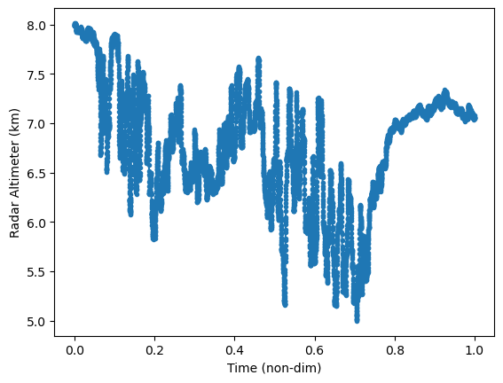

```python
s.plot_altimeter( 1)
```

```python
s.run( samples=10000 )
```

PyMC converges in 10000 samples to extremely tight posterior distributions such that tools like `arviz.summary` find the correct mean initial conditions and round the standard deviations to zero.

```python
s.summary(1)
```

|  | mean | sd | hdi_3% | hdi_97% | mcse_mean | mcse_sd | ess_bulk | ess_tail | r_hat |
| --- | --- | --- | --- | --- | --- | --- | --- | --- | --- |
| θ0 | -122.254 | 0.0 | -122.254 | -122.254 | 0.0 | 0.0 | 8733.0 | 16394.0 | 1.0 |
| φ0 | 47.589 | 0.0 | 47.589 | 47.589 | 0.0 | 0.0 | 6478.0 | 12261.0 | 1.0 |
| V0 | 10.000 | 0.0 | 10.000 | 10.000 | 0.0 | 0.0 | 6009.0 | 11519.0 | 1.0 |
| σ | 0.010 | 0.0 | 0.010 | 0.010 | 0.0 | 0.0 | 16627.0 | 26435.0 | 1.0 |

Manual inspection of the posterior distribution shows that the credible sets for $\theta$ and $\phi$ are approximately 0.00004 degrees in size. Given that a single pixel is 0.008 degrees wide that means that the resolution increases to subpixel accuracy by a factor of over 100.

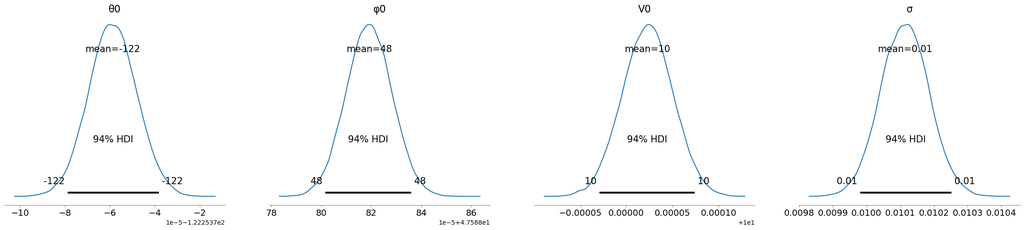

```python
s.posterior_initial(4)
```

Plotting the 95% credible set compared to the truth shows that the error in $\theta$ stays on the order of $\pm 1e-5$ degrees with a slight change in bias due to velocity error in the $\theta$ direction. Similar accuracy results from a measurement of $\phi$. The credible set in this estimate is the narrowest between time of 0.3 and 0.6. The altitude measurement plot shows that the area of most variablitiy in terrain is in this period. This mirrors the two dimensional case such that the best resolution occurs when flying over areas with unique and variable terrain.

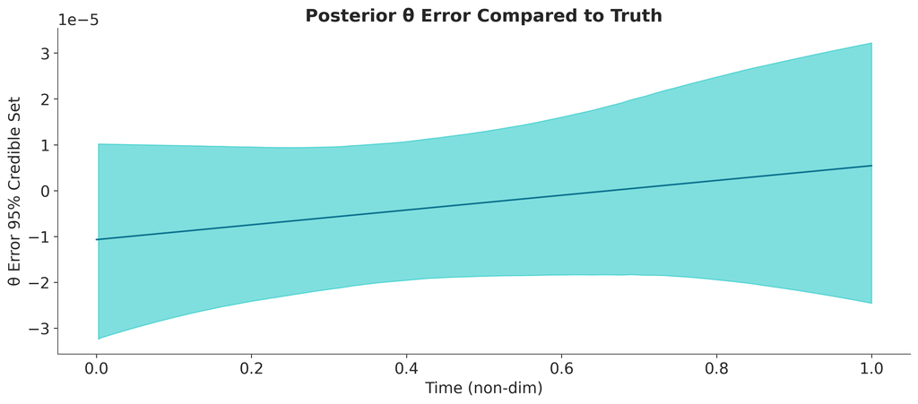

```python
s.plot_θ_credible(5)
```

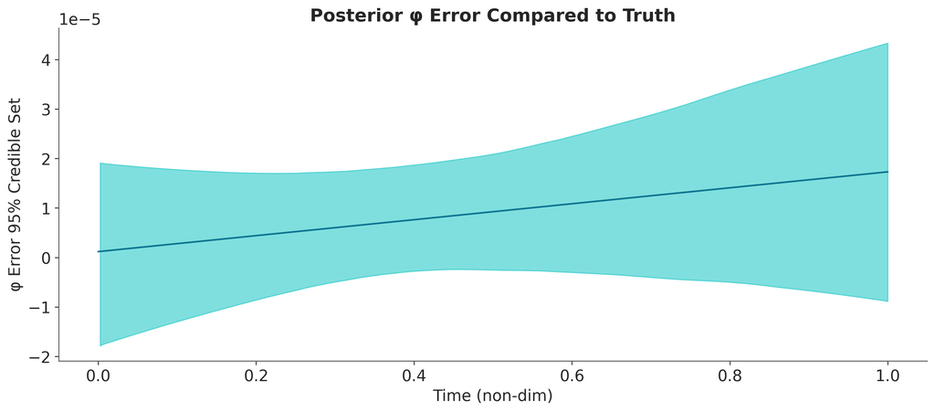

```python
s.plot_φ_credible(6)
```

## Summary of 3-D Estimation

Estimation of steady level flight trajectories work well in three dimensions. The model used is somewhat restricted in that $\gamma$ and $H$ are known. However, more variablity could be added with a larger sample size. The first case was unrealistic because of the 2-dimensional assumption. In the 3-dimensional case the assumptions are more realistic. A random flight track from United Airlines shows that once cruising altitude is achieved the steady level flight assumption is reasonable. Altitude and velocity are somewhat constant but are most certainly "piecewise constant" which means that flight could be broken into a series of steady level flight conditions.

[figure not shown]

However there are small changes in altitude and velocity. An autoregressive model should be inspected to characterize these changes.

# Conclusions

In this project we explored using Markov Chain Montecarlo (MCMC) to solve the navigation problem via terrain matching. At its core this problem is a rather simple linear regression. Understanding and effectively employing this method requires proper non-dimensionalization of time and selection of the prior distributions such that an adequate number of terrain pixels will be searched in the right amount of samples. Having a sufficiently high altimeter sample resolution is also critical to the performance of this method. If the samples are not dense enough and they skip over multiple map pixels then there is a higher chance of failed convergencce. This method succeeds at achiving subpixel reslution in the posteriors and provides a full set of position samples across the entire sample space. The algorithm does require significant computation and could be improved upon with hardware acceleartion via a GPU or FPGA. Finally, this method does suffer from a potential false convergence in some cases where a solution is found with high altimeter noise which effectively "washes out" the terrain map. While its possible for this case to occur with good convergence $\hat{r}$ values it does not converge to correct locations. To avoid this case proper constraints on the altimeter noise prior should be selected to make this type of convergence impossible. Given that the noise performance of an alimiter will be provided by most vendors this should not be difficult in practice.

In the future this algorithm could be explored in other scenarios in more detail. Chaining multiple runs together where the posterior from previous run becomes prior for the next run. This would allow solution of flight paths where the steady level flight assumption is expanded to 'piecewise' steady level flight. Since, the posteriors from the initial solution will have small variance this means that in follow on parts of the chain that other variables like $\gamma$ and $H$ could be left free to represent altitude or heading change and be solved without massive increase in the number of samples required. Integration of the MCMC algorithm with an extended kalman filter and IMU would allow total abandonment of the steady level flight assumption and allow for complex trajectories to be solved. Finally this method could be compared against other terrain aided navigation techniques which rely on digital elevation models such as presented in [1,2,3]

# References

1. B. Turan and A. T. Kutay, "Particle filter studies on terrain referenced navigation," 2016 IEEE/ION Position, Location and Navigation Symposium (PLANS), Savannah, GA, USA, 2016, pp. 949-954, doi: 10.1109/PLANS.2016.7479793.
2. Jason D. Carroll and Aaron J. Canciani NAVIGATION: Journal of the Institute of Navigation March 2021, 68 (1) 115-134; DOI: https://doi.org/10.1002/navi.406
3. Bergman, N., Ljung, L., & Gustafsson, F. (1999). Terrain navigation using Bayesian statistics. IEEE Control Systems Magazine, 19(3), 33–40. https://doi.org/10.1109/37.768538